# Comparing Machine Learning Models for Ratemaking

10 October 2018

# Introduction

Today I walked to a nearby Cafe Nero in Boston to use their wifi while writing this. I ordered a small english breakfast tea with no sugar. This delicious hot beverage had a price of $2.49. Why was it $2.49? Why not $249.00? Why not $5.00 or $10.00? Is it because $2.49 is the cost of a cup of tea anywhere else in Boston? Is there a Massachusetts law which sets limits on prices for breakfast beverages? Is it because the demand and supply curves tell it to be $2.49?

Regardless of how the price is determined, the product purchased is the same cup of tea. If I were to buy 100 cups of tea, they would all taste the same and cost Cafe Nero the same amount in order to produce. This is to say, the cost of a cup of tea from the perspective of the seller is constant.

If Cafe Nero was selling me an insurance product, then this would be a different story. Let’s say that Cafe Nero sold me auto insurance for the next 12-months for $2.49. Would this be a fair price? This would depend on a number of factors such as my driving record, the value of my car, and the number of miles that I drive. The goal of ratemaking in insurance is to set premiums which are not too high and not to low. **My goal is to compare the traditional method for pricing claims using Generalized Linear Models (GLMs) with newer machine learning approaches while following papers published by the Casualty Actuarial Society (See Sources section).

**Insurance Terms:**

- **Exposure:** A measure of the amount of risk hazard. This is usually the length of coverage term. This can also be the number of miles driven.
- **Loss Amount:** This is the dollar amount of actual damage that my car takes.
- **Severity:** The dollar amount paid from an insurance company to the insured. In auto insurance, this is the amount the insurance company pays to repair my car.
- **Frequency:** The number of claims that are filed for a given policy period. Longer policy periods have more claims filed on average.
- **Deductible:** The amount paid by the insured when a claim is filed. For example, if my Cafe Nero Auto Insurance plan has a $1000 deductible, then if I then if my car costs $2000 to fix, I will pay $1000 and Cafe Nero will pay $1000.

**Model Objective**:

$$\\
\text{E[Loss]} = \text{E[Number of Claims]} \cdot \text{E[Cost per claim]} = \text{E[Frequency]} \cdot \text{E[Severity]}
\\$$

Because `frequency` is assumed to be independent of `severity`, the expected value of the product is the product of the expected values. Another method is to model the amount of risk per unit exposure directly, known as $\text{Pure Premium} = \tfrac{\text{Dollars of Loss}}{\text{Exposure}}$ directly. This does not provide as much inference in to the data, so I chose to go with the first approach.

## Exploratory Data Analysis (EDA)

This data set is based on one-year vehicle insurance policies taken out in 2004 or 2005. There are 67,856 policies. Each record represents a single policyholder, over a set coverage period, for a given vehicle, along with other policy-level characteristics. Anyone can access this data from the R package `insuranceData`.

| Feature | Description |
| --- | --- |
| veh_value | The value of the vehicle in $10,000s |
| exposure | Percentage of year of coverage from 0-1 |
| clm | Whether a claim was filed |
| numclaims | The number of claims filed |
| claimcst0 | Claim amount (including 0 for no claim) |
| veh_body | vehicle body type |
| veh_age | 1 (youngest), 2, 3, 4 |
| gender | Gender of policyholder |
| area | Geographic region |
| agecat | 1 (youngest), 2, 3, 4, 5, 6 |
| X_OBSTAT_ | No description provided |

We look at the distributions and see that `veh_value` and `claimcst0` are heavily right-skewed. The `exposure` of policyholders is approximately uniform, which is what we would expect.

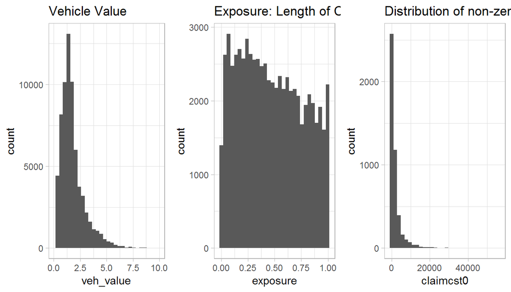

```r
data(dataCar)

car <- dataCar %>%
  mutate_at(c("clm", "agecat", "X_OBSTAT_", "veh_body"), as.factor) %>%
  #because ther are only a few roadsters, these are being grouped together as sports cars
  mutate(veh_body = as.character(veh_body),
         veh_body =  as.factor(ifelse(veh_body %in% c("RDSTR", "CONVT"), yes = "SPRT", no = veh_body)))

p1 <- car %>%
  ggplot(aes(veh_value)) +
  geom_histogram() +
  xlim(0, 10) +
  ggtitle("Vehicle Value")  +
  theme_light()

p2 <- car %>%
  ggplot(aes(exposure)) +
  geom_histogram() +
  ggtitle("Exposure: Length of Coverage Term") +
  theme_light()

p3 <- car %>%
  dplyr::filter(claimcst0 > 0) %>%
  ggplot(aes(claimcst0)) +
  geom_histogram() +
  ggtitle("Distribution of non-zero severity") +
  theme_light()

grid.arrange(p1, p2, p3, ncol = 3)
```

The data is being split into two data sets: once for modeling the frequency with all claims included, and another for modeling the severity where zero-pay claims are dropped.

We see that the most severe accidents are for family vehicles and daily drivers, such as trucks, sedans, and hatchbacks. The laest severe claims are for weekend cars such as sports cars, hard tops, and busses. These are vehicles that do not get driven as often.

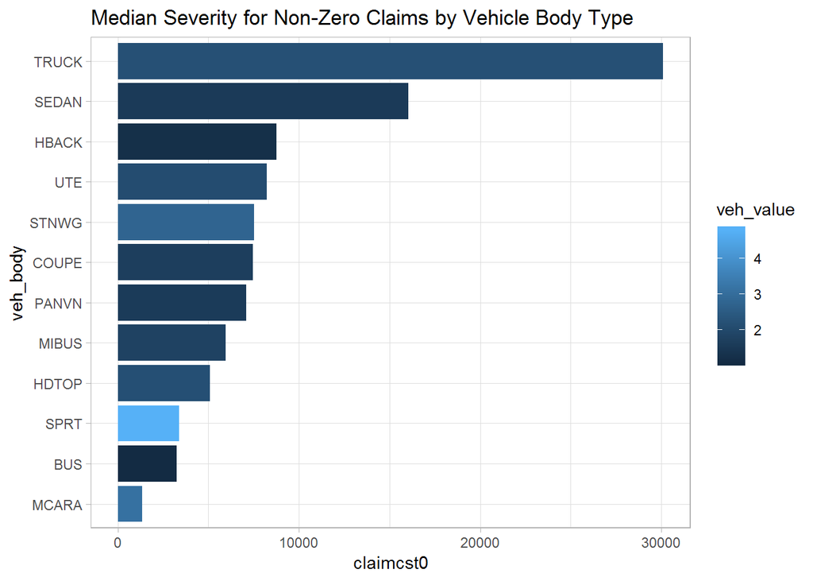

```r
severity_order <- car %>%
  group_by(veh_body) %>%
  filter(claimcst0 > 0 ) %>%
  summarise(claimcst0 = mean(claimcst0/exposure, na.rm = T)) %>%
  arrange(claimcst0) %>%
  select(veh_body) %>%
  unlist() %>%
  as.character()

car %>%
  group_by(veh_body) %>%
  filter(claimcst0 > 0 ) %>%
  summarise(claimcst0 = mean(claimcst0/exposure, na.rm = T),
            veh_value = mean(veh_value, na.rm = T)) %>%
  ggplot(aes(y = claimcst0, x = veh_body, fill = veh_value)) +
  geom_bar(stat = "identity") +
  coord_flip() +
  ggtitle("Median Severity for Non-Zero Claims by Vehicle Body Type") +
  scale_x_discrete(limits = severity_order) +
  theme_light()
```

When looking at the average frequency of accidents, we see that busses have an highest frequency of accidents but the 2nd lowest severity. Although trucks have a high average severity, they are in accidents about the same number of times per exposure period as smaller passenger cars. Hard tops (a type of sports car) have lower severity but greater frequency than SUV’s.

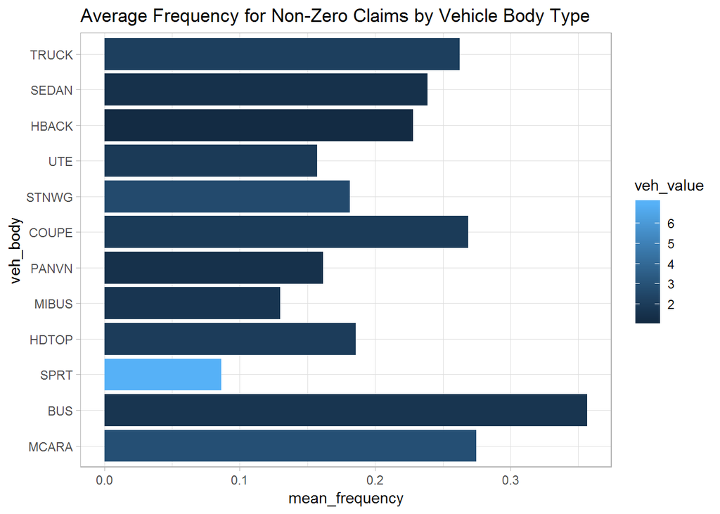

```r
car %>%
  group_by(veh_body) %>%
  summarise(mean_frequency = sum(numclaims/exposure, na.rm = T)/n(),
            veh_value = mean(veh_value, na.rm = T)) %>%
  ggplot(aes(y = mean_frequency, x = veh_body, fill = veh_value)) +
  geom_bar(stat = "identity") +
  coord_flip() +
  ggtitle("Average Frequency for Non-Zero Claims by Vehicle Body Type")+
  scale_x_discrete(limits = severity_order) +
  theme_light()
```

The most severe accidents total the car because there are no subsequent claims. What happens when the claim cost is greater than the vehicle’s value? When a vehicle is totaled, the policy can have no additional claims. This means that the majority of the large losses will occur with only one claim on the policy.

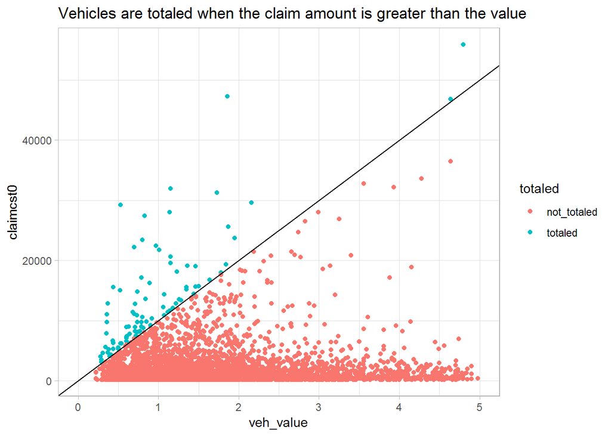

```r
car %>%
  filter(claimcst0 > 0, veh_value > 0) %>%
  mutate(totaled = ifelse(claimcst0 > veh_value*10000, "totaled", "not_totaled")) %>%
  ggplot(aes(veh_value, claimcst0, color = totaled)) +
  geom_point() +
  xlim(0, 5) +
  geom_abline(slope = 10000, intercept = 0) +
  ggtitle("Vehicles are totaled when the claim amount is greater than the value") +
  scale_fill_manual(values=c( "deepskyblue3", "dodgerblue4")) +
  theme_light()
```

```r
car %>%
  mutate(gender = ifelse(gender == "F", "women", "men")) %>%
  group_by(gender, veh_body) %>%
  summarise(total_value = sum(veh_value)) %>%
  spread(gender, total_value) %>%
  transmute(
    charriott_of_choice = veh_body,
    women = women/(women + men)*100,
    men = men/(women + men)*100,
    difference = men - women) %>%
  arrange(desc(difference))
```

| charriott_of_choice | women | men | difference |
| --- | --- | --- | --- |
| TRUCK | 22.11883 | 99.25319 | 77.13437 |
| PANVN | 21.95280 | 97.53779 | 75.58499 |
| UTE | 28.56287 | 99.55283 | 70.98996 |
| HDTOP | 44.74838 | 97.54837 | 52.79999 |
| STNWG | 48.74953 | 99.78154 | 51.03201 |
| MCARA | 38.07112 | 85.79177 | 47.72065 |
| COUPE | 48.53858 | 94.20650 | 45.66791 |
| SEDAN | 60.18160 | 99.54922 | 39.36762 |
| SPRT | 51.47848 | 87.68683 | 36.20834 |
| MIBUS | 59.78129 | 89.17498 | 29.39369 |

[output cut: 2 more lines]

## Insurance Deductibles

Insurance plans generally have a deductible. This is a fixed amount that the insured must pay each time a claim is filed, and no claim can be filed for an amount less than the deductible. This is to provide an disincentive to the insured towards risky behavior. According to [Investopedia](https://www.investopedia.com/ask/answers/071515/why-do-insurance-policies-have-deductibles.asp),

> Deductibles mitigate the behavioral risk of moral hazards. A moral hazard describes the risk that two parties to an agreement or contract may not act in good faith. >Because insurance policies protect the policyholder from loss, a moral hazard exists; the insured party may engage in risky behavior due to the protection provided by >the insurance policy he holds.

```r
car %>%
  mutate(claim_amount = round(claimcst0, 0)) %>%
  group_by(claim_amount) %>%
  summarise(percent_of_claims = 100*n()/nrow(car)) %>%
  arrange(desc(percent_of_claims)) %>%
  top_n(5)
```

| claim_amount | percent_of_claims |
| --- | --- |
| 0 | 93.1855694 |
| 200 | 1.0507545 |
| 354 | 0.3831643 |
| 390 | 0.2240038 |
| 368 | 0.0648432 |

[figure not shown]

```r
car <- car %>%
  mutate(deductible = as.factor(ifelse(round(claimcst0, 0) %in% c(200, 354, 390, 345) , "deductible", "no_deductible")))

car %>%
  filter(claimcst0 > 0) %>%
  mutate(claimcst0 = log(claimcst0)) %>%
  ggplot(aes(claimcst0, fill = deductible)) +
  geom_histogram() +
  ggtitle("Many Claims are exactly $200 or $345 due to Insurance Deductibles") +
  xlab("Log of Severity") +
  scale_fill_manual(values=c( "deepskyblue3", "dodgerblue4")) +
  theme_light()
```

For a loss amount $X$, the distribution of the claim amount $Y$ afer the deductible $d$ is

$$P[Y = y] = P[X - d | X > d]$$
This is a very common problem in insurance data, and the author cites several methods for fixing this. The simplest approach is to use `deductible` as a new feature. We would also remove the deductibles and fit a distribution to fill in the amounts less than the deductible, after adjusting the maximum likelihood estimate for truncation. The most throrough approach is to remove these from the data and model them seperately.

## Correlation with Severity

We look for linear relationships between the features. Most of these correlations are intuitive, such as

- vehicle age is negatively correlated with value given that cars depreciate in value over time
- As the length of coverage increases, `exposure`, there is an increase in the frequency of claims. More on this later.
- There is no correlation between the vehicle’s age the the number of claims. We would expect that the risk of an accident does not directly depend on the age of the vehicle, but here could be non-linear relationships here. For example, vehicle’s which the owner has just purchased could be at a higher risk due to the driver having less experience behind the wheel

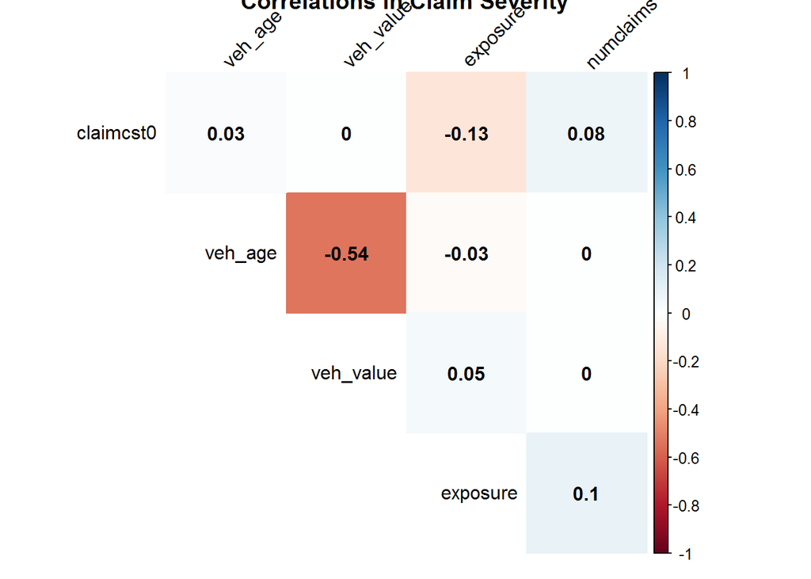

```r
car %>%
  filter(claimcst0 > 0) %>%
  select_if(is.numeric) %>%
  as.matrix() %>%
  na.omit() %>%
  cor() %>%
  corrplot(
    method = "color",
    type = "upper",
    order="hclust",
    addCoef.col = "black", # Add coefficient of correlation
    tl.col="black",
    tl.srt=45, #Text label color and rotation
    # Combine with significance
    #p.mat = p.mat,
    sig.level = 0.01,
    insig = "blank",
    title = "Correlations in Claim Severity",
    # hide correlation coefficient on the principal diagonal
    diag=F)
```

When looking the complete data, regardless of whether a claim was filed or not, there is a slightly different picture.

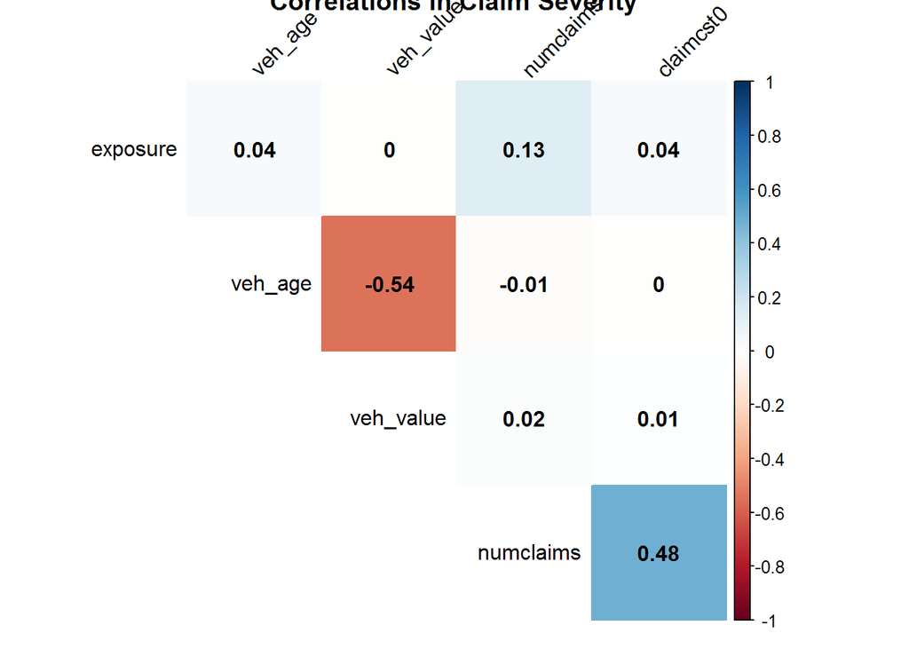

```r
car %>%
  select_if(is.numeric) %>%
  as.matrix() %>%
  na.omit() %>%
  cor() %>%
  corrplot(
    method = "color",
    type = "upper",
    order="hclust",
    addCoef.col = "black", # Add coefficient of correlation
    tl.col="black",
    tl.srt=45, #Text label color and rotation
    # Combine with significance
    #p.mat = p.mat,
    sig.level = 0.01,
    insig = "blank",
    title = "Correlations in Claim Severity",
    # hide correlation coefficient on the principal diagonal
    diag=F)
```

# Data Preparation

The goal of this step is to put the data into the right shape for modeling.

The target of the severity model is the average loss amount per claim. We have already added indicator variables for deductibles. The author recommends taking the log transform of any continuous features if a log-link is used (see GLM section below).

```r
severity <- car %>%
  filter(claimcst0 > 0) %>%
  mutate(
    avg_loss = claimcst0 / numclaims)
```

Even insurance companies have limits to the amount of risk that they will insure. They set limits to the highest claim amount that they will cover, and can then pass the amount above these claims on the reinsurance companies. This is known as ceeding risk. The range of claim values that are covered is known as the *coverage layer*.

Another item which can improve the model outcomes is related to the factor levels. This is related to how R chooses base levels (AKA, reference levels). The author says to set these to the levels which have the largest sample sizes in order to reduce the variance of the parameters in GLMs. Fortunately, the library `forcats` has a function designed specifically to do just this in just two lines of code!

```r
car <- car %>%
  mutate_if(is.factor, fct_infreq)
```

```r
avg_loss_cap <- quantile(severity$avg_loss, 0.95)

severity <- severity %>%
  mutate(
    avg_capped_losss = ifelse( avg_loss < avg_loss_cap, avg_loss, avg_loss_cap),
    large_loss = as.factor(ifelse(avg_loss > avg_loss_cap, "Yes", "No"))) %>%
  select(-clm, -X_OBSTAT_) # drop features which provide no additional information

severity %>%
  select(large_loss) %>%
  summary()
```

```
##  large_loss
##  No :4392
##  Yes: 232
```

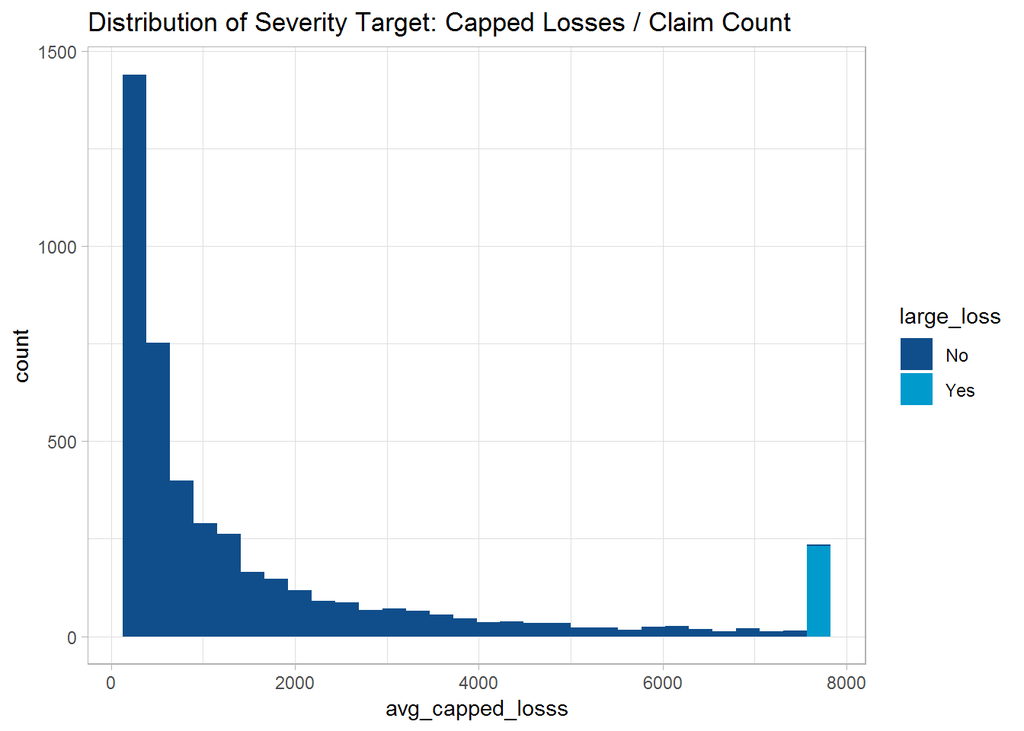

```r
severity %>%
  ggplot(aes(avg_capped_losss, fill = large_loss)) +
  geom_histogram() +
  ggtitle("Distribution of Severity Target: Capped Losses / Claim Count") +
  scale_fill_manual(values=c("dodgerblue4","deepskyblue3")) +
  theme_light()
```

# Model Design

The model design will be as follows

$$\text{E[Future Losses]} = \text{E[Frequency]} \text{E[Severity]} +
\text{E[Number of deductible losses]} \text{[Deductible]} +
\text{E[Number of capped losses]}\text{[Cap]}$$
There will be four final models selected: frequency, severity, and count models for the number of deductible claims and the number of capped claims For the count models we can use Poisson regression.

We split the data into a training and testing set.

```r
set.seed(1)
severity_train_index <- createDataPartition(severity$avg_capped_losss, times = 1, p = 0.7, list = FALSE) %>% as.vector()

train_severity <- severity %>%
  slice(severity_train_index) %>%
  filter(deductible == "no_deductible", large_loss == "No")

test_severity <- severity %>%
  slice(- severity_train_index) %>%
  filter(deductible == "no_deductible", large_loss == "No")

frequency_train_index <- createDataPartition(car$numclaims, times = 1, p = 0.7, list = FALSE) %>% as.vector()

train_frequency <- car %>%
  slice(frequency_train_index)

train_frequency <- car %>%
  slice(- frequency_train_index)
```

# GLM Models for Severity

To explain Generalized Linear Models (GLMs), let’s first start with an explanation of a simpler version, Ordinary Least Squares (OLS).

The item we are trying to prdict is $Y$, and the data that we have is a matrix $X$ where each column is a feature. For a given data set $X$, we want to be able to make an accurate guess as to $Y$. The error of the guess is $\mathcal{E}$, which is centered at zero.

The first assumption is that $Y$ is a linear function of the features. That is, using the data, we can make predictions about X using only addition and multiplication.

$$Y = X\beta + \mathcal{E}$$
Because X and $\beta$ are both constants, their expected value is just themselves. The error term has expected value zero because we expect the estimates to “miss” above and below the target an equal number of times.

$$\mu = E[Y] = E[X\beta] + E[\mathcal{E}] = X\beta$$

The value $\beta$ is determined by minimizing the error term. Using calculus, this is as simple as taking the derivative of $(Y - E[Y])^T(Y - E[Y])$ with respect to $\beta$, setting it equal to zero, and solving.

The second main assumption is that the response $y$ is normally distributed That is, $\mathcal{y} \sim N(\mu, \sigma^2)$.

$$P[Y = y| X] = f(y; \mu) = \frac{1}{\sqrt{2\pi\sigma^2}}\exp(- \frac{(y - \mu)^2}{2\sigma^2})$$

Making this above guess at the shape of $Y$ has little basis in reality and is for convenience. To make a GLM, all that we need is to relax the previous two assumptions. Instead of assuming that $Y$ is directly a linear function of $X$, we allow for certain functions to connect the two. We call this the *link* function $g(.)$.

$$g[E[Y]] = X\beta$$

We do still place limits as to what $g(.)$ can be. In fact, often times this is just the natural logarithm. This is because $log(.)$ has several nice properties, such as the fact that positive values stay positive and the variance decreases.

When relaxing the constraing on the shape of $y$, we allow for any member of the exponential family of distributions. This includes any random variable with a PDF which can be written as $e^\text{Something}$. For example, if modeling count data, a Poisson distribution is the common fit, and we can write the Poisson’s PDF in expoential form with some clever algebra. For $y \sim Pois(\lambda)$,

$$f(y; \lambda) = \frac{\lambda^ye^-\lambda}{y!}$$

Recall that $e^{log(\text{Something})} = \text{Something}$ which implies

$$f(y; \lambda) = \exp(-\lambda + y log(\lambda) - log(y!))$$

And this is of the exponential form $e^\text{Something}$, which means that we can model Poisson distributed $Y$’s. Other distributions in the exponential family are the binomial, normal, gamma, negative binomial, and the Tweedie, which is used specifcally in insurance claims contexts.

```r
#using only the mean response
glm_baseline <- glm(
  formula = avg_capped_losss ~ 1,
  family = Gamma(link = "log"),
  data = train_severity,
  weights = train_severity$numclaims)

#using only the length of time of coverage
vars_1 <- "exposure"
glm_severity_1 <- glm(
  formula = avg_capped_losss ~ exposure,
  family = Gamma(link = "log"),
  data = train_severity,
  weights = train_severity$numclaims)

vars_2 <- "exposure, log(veh_value)"
glm_severity_2 <- glm(
  avg_capped_losss ~ exposure + log(veh_value + 0.001),
  family = Gamma(link = "log"),
  data = train_severity,
  weights = train_severity$numclaims)

vars_3 <- "exposure, log(veh_value), veh_age, gender"
glm_severity_3 <- glm(
  avg_capped_losss ~ exposure + log(veh_value + 0.001) + veh_age + gender,
  family = Gamma(link = "log"),
  data = train_severity,
  weights = train_severity$numclaims)

vars_4 <- "exposure, log(veh_value), numclaims, veh_age, gender"
glm_severity_4 <- glm(
  avg_capped_losss ~ log(veh_value + 0.001) + exposure + numclaims + veh_age + gender,
  family = Gamma(link = "log"),
  data = train_severity,
  weights = train_severity$numclaims)

vars_5 <- "veh_value, exposure, numclaims, veh_age, gender, area"
glm_severity_5 <- glm(
  avg_capped_losss ~ veh_value + exposure + numclaims + veh_age + gender + area,
  family = Gamma(link = "log"),
  data = train_severity,
  weights = train_severity$numclaims)
```

Creating lists of models makes comparisons easier.

```r
severity_glms <- list(glm_severity_1, glm_severity_2, glm_severity_3, glm_severity_4, glm_severity_5)
```

We compare all of the models based on several fitting criteria. These are

- **Deviance:** This is a generalization of the sum of squares to GLMs which compares the likelihood of the current model to the likelihood of a saturated model with all parameters included.

For the predicted value $\mu$ of response $y$, the deviance $D$ is

$$D(y, \mu) = 2(log(p(y | \theta_s) - log(y|\theta_0)) )$$

Where $\theta_s$ is the the set of parameters of the fully saturated model. This is the model whic fits the data perfectly by having one parameter for each observation. $\theta_0$ is the current set of parameters for the model being tested.

- **Akaike Information Criterion (AIC):** AIC tries to select a model which matches an unknown, high-dimensional reality. A lower AIC is better. The formula is

$$\text{AIC} = 2k - log(L)$$

where k is the number of parameters and L is the value of the maximum value of the likelihood function for the model. AIC penalizes overfitting because as more features are added to the model, the number of parameters k increases, which results in a higher AIC.

- **Bayesian Information Criterion (BIC):** This assumes that within the set of candidate models is a “true” model. Although this is an unrealistic assumption it does allows us to compare models side-by-side. Just like AIC, lower is better. The formula for BIC is

$$\text{BIC} = log(n)k - 2log(L)$$

There is a lot of debate about whether AIC or BIC should be used. A good rule of thumb is to use both, and if they disagree in that AIC is larger but BIC smaller or vice versa, to use an alternative method to differentiate such as cross-validation.

```r
GLM_summaries <- data_frame(features = c(vars_1, vars_2, vars_3, vars_4, vars_5)) %>%
  cbind(
    severity_glms %>%
    map_dfr(glance) %>%
    select(-null.deviance, -df.null, -logLik)
  ) %>%
  mutate(final_model = ifelse(row_number() == 4, 1, 0))

GLM_summaries %>%
  datatable(rownames = F) %>%
  formatStyle(
  'final_model',
  target = 'row',
  backgroundColor = styleEqual(c(0, 1), c('white', 'grey'))
)
```

[output not shown]

```r
summary(glm_severity_4)
```

[output not shown]

```r
#Get the root mean squared error for a glm from test data.
get_GLM_RMSE <- function(input_model, test_data) {
  mu <- predict.glm(input_model, test_data, type = "response", se.fit = T)$fit
  y <- test_data$avg_capped_losss
  #return the square root of the squared error
  sqrt(sum((y - mu)^2/length(y)))
}

get_GLM_RMSE(input_model = glm_severity_4, test_data = test_severity)
get_GLM_RMSE(glm_baseline, test_data = test_severity)
```

[output not shown]

## Gradient Boosted Trees

Gradient Bosted Machines (GBMs) are one of the best off-the-shelf models in the world (Elements of Statistical Learning, 302). There are many variantions of GBM algorithms, but the overall structure is consistent and looks as follows.

1. Initialize the observation weights $w_i = \frac{1}{N}, i = 1, 2, ..., N$
2. For $m = 1$ to $M$:
1. Fit a weak learner $G_m(x)$ to the training data using weights for the observations $w_i$
2. Compute an error rate for this learner which measures how well the weak learner predicts on the test set
3. Use this error rate to update the weights $\{w_1, ... , w_N\}$
3. Output a final set of predictions $G(x)$ as a linear combination of $\{G_1(x), ..., G_m(x)\}$

The “weak learner” $G(.)$ is usually a regression or classification tree. The tuning parameters for a GLM are as follows.

- The number of iterations, i.e. trees, which is $m$, defined as `n.trees`
- The complexity of the tree, called the interaction depth, `interaction.depth`.
- The learning rate: how quickly the algorithm adapts, called `shrinkage`. The lower the learning rate, the better the model, but the more trees are required, and for each additional tree that is added there is a diminishing return of added performance. Compute power is the main limitaiton to the number of trees that can be used.
- The minimum number of training set samples in a node to commence splitting, `n.minobsinnode`. If this is too small, then the model will overfit to specific observations; too high and the model will miss picking up signal.

The model tuning process involves computing many combinations of these parameters and choosing the model with the highest performance on the test data. We test out several values of the input parameters and evaluate the cross-valideated RMSE. After testing out different combinations with a grid search, I found that 400 trees with an interaction depth of 2, a learning rate of 0.01, and 50 minimum observations per node to give the best results on the test set.

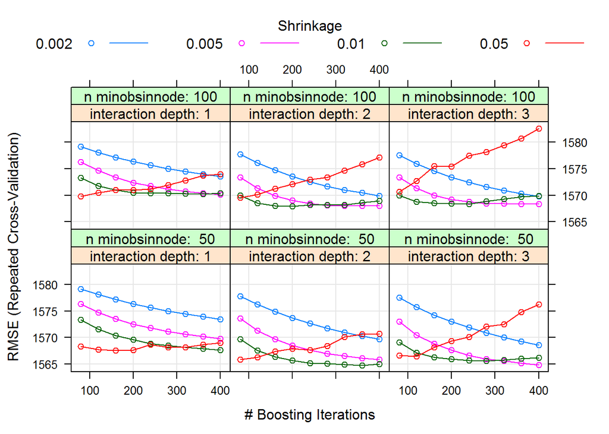

```r
fitControl <- trainControl(## 10-fold CV
                           method = "repeatedcv",
                           number = 10,
                           ## repeated ten times
                           repeats = 2)

gbmGrid <-  expand.grid(interaction.depth = c(1, 2, 3), #most of the time this is sufficient
                    n.trees = (2:10)*40,
                    shrinkage = c(0.002, 0.005, 0.01, 0.05),
                    n.minobsinnode = c(50, 100))


gbm_severity <- train(
  avg_capped_losss ~ veh_value + exposure + veh_age + gender + area + agecat + numclaims + veh_body,
  data = train_severity,
  method = "gbm",
  trControl = fitControl,
  tuneGrid = gbmGrid,
  verbose = FALSE)

#saveRDS(gbm_severity, file)
plot(gbm_severity)
```

We can compare the predictive power of the different features from the GBM by looking at the variable importance. This is based on the number of times that a variable is used for splitting, and weighted by the squared improvement in the model as a result of the split, and averaged over all the trees [Elith et al. 2008, A working guide to boosted regression trees](https://besjournals.onlinelibrary.wiley.com/doi/full/10.1111/j.1365-2656.2008.01390.x)

```r
#there must be a better way of getting these factor levels be sorted on the graph...
importance_order <- data_frame(
  feature = rownames(varImp(gbm_severity$finalModel)),
  importance = varImp(gbm_severity$finalModel)$Overall) %>%
  arrange(importance) %>%
  select(feature) %>%
  unlist() %>%
  as.character()

data_frame(
  feature = rownames(varImp(gbm_severity$finalModel)),
  importance = varImp(gbm_severity$finalModel)$Overall) %>%
  mutate(feature = fct_relevel(feature, importance_order)) %>%
  ggplot(aes(feature, importance)) +
  geom_bar(stat = "identity") +
  coord_flip() +
  ggtitle("Feature Importance from GBM for Severity")
```

[output not shown]

The partial dependence plots show the impact of the predictors on the data. From the `exposure` graph, you can see a seasonal pattern in the fraction of the year of coverage. Is this because once a driver is in an accident they are less likeloy to cancel their coverage?

Is this because policyholders who have been insured longer are in more severe accidents or less severe accidents? Perhaps riskier drivers buy longer coverage terms, or maybe commercial drivers who are constantly on the road have policies which are auto-reknewed by their employer?

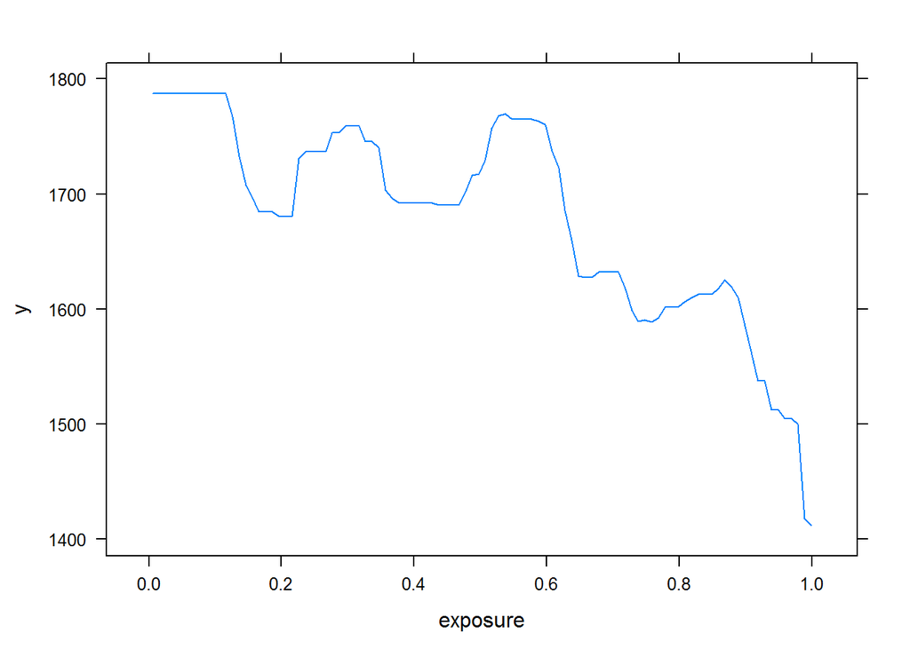

```r
par(mfrow = c(2,2))
vars <- c("exposure", "veh_value", "numclaims", "areaC", "genderM", "veh_age")
plot.gbm(gbm_severity$finalModel, i.var = c("exposure"))
```

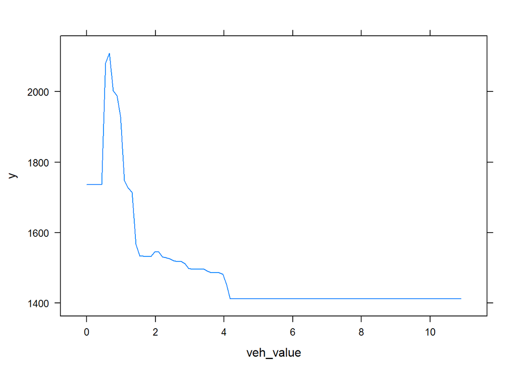

```r
plot.gbm(gbm_severity$finalModel, i.var = "veh_value")
```

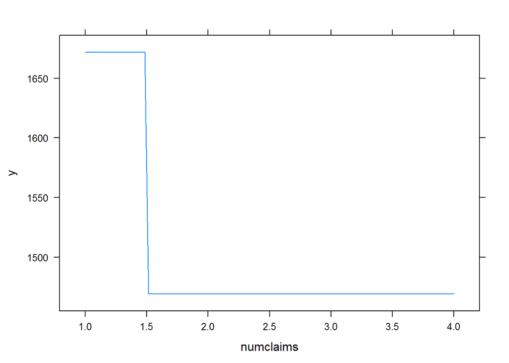

```r
plot.gbm(gbm_severity$finalModel, i.var = "numclaims")
```